# NBA - CV y Regularización

Andrea Jiménez Zúñiga

11/3/2020

```r
library(here) # Comentar
library(tidyverse)
library(janitor) # Clean names
library(skimr) # Beautiful Summarize
library(magrittr) # Pipe operators
library(corrplot) # Correlations
library(ggcorrplot)  # Correlations
library(PerformanceAnalytics) # Correlations
library(leaps) # Model selection
library(readr)
library(rsample)
library(glmnet)
library(dplyr)
library(ggplot2)
```

## Read Data

```r
nba_data <- read_csv("nba.csv")
colnames(nba_data)
```

```
##  [1] "Player"          "Salary"          "NBA_Country"     "NBA_DraftNumber"
##  [5] "Age"             "Tm"              "G"               "MP"
##  [9] "PER"             "TS%"             "3PAr"            "FTr"
## [13] "ORB%"            "DRB%"            "TRB%"            "AST%"
## [17] "STL%"            "BLK%"            "TOV%"            "USG%"
## [21] "OWS"             "DWS"             "WS"              "WS/48"
## [25] "OBPM"            "DBPM"            "BPM"             "VORP"
```

## Nombre Variables

```r
nba_data %<>% clean_names()
colnames(nba_data)
```

```
##  [1] "player"           "salary"           "nba_country"      "nba_draft_number"
##  [5] "age"              "tm"               "g"                "mp"
##  [9] "per"              "ts_percent"       "x3p_ar"           "f_tr"
## [13] "orb_percent"      "drb_percent"      "trb_percent"      "ast_percent"
## [17] "stl_percent"      "blk_percent"      "tov_percent"      "usg_percent"
## [21] "ows"              "dws"              "ws"               "ws_48"
## [25] "obpm"             "dbpm"             "bpm"              "vorp"
```

```r
# delete duplicate
# Remove duplicate rows of the dataframe
nba_data %<>% distinct(player,.keep_all= TRUE)

# delete NA's
nba_data %<>% drop_na()
```

## Model Selection

```r
set.seed(1234)
data_split <- initial_split(nba_data, prob = 0.70, strata = "salary")
data_train <- training(data_split)
data_test  <-  testing(data_split)
```

Creación de matrices para training y testing y vectores.

```r
data_train_x <- model.matrix(salary ~., data_train)[,-1]
data_train_y <- log(data_train$salary)

data_test_x <- model.matrix(salary ~., data_test)[,-1]
data_test_y <- log(data_test$salary)
```

Dimensión de mi nueva matriz

```r
dim(data_train_x)
```

```
## [1] 363 454
```

Ridge regression:

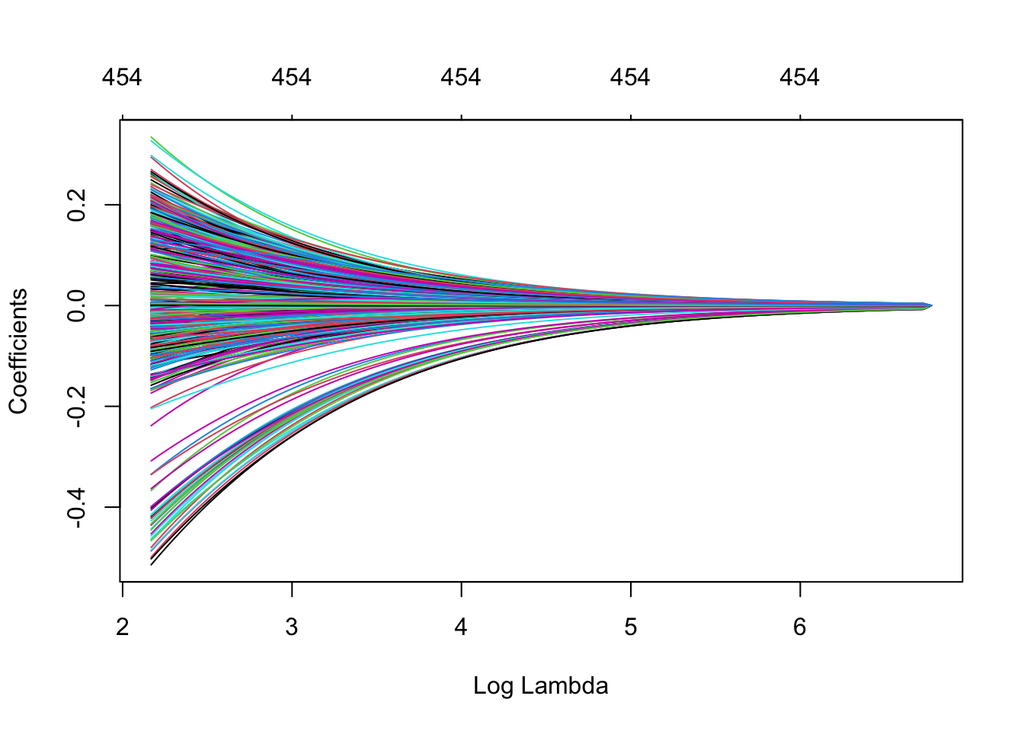

```r
data_ridge <- glmnet(
  x= data_train_x,
  y= data_train_y,
  alpha = 0
)

plot(data_ridge, xvar = "lambda")
```

```r
data_ridge$lambda %>% head()
```

```
## [1] 874.4999 834.7526 796.8118 760.5955 726.0252 693.0263
```

## TUNNING

Aplicar Cross Validation a los datos.

Los errores de predicción son los puntos rojos. Conforme voy aumentando, aumenta lambda. La segunda línea es la desviación típica, es decir, que entre esos dos puntos (de las dos líneas) no podemos predecir cuál es el mejor lambda. Cuanto más a la derecha esté en el gráfico más sencillo va a ser el modelo.

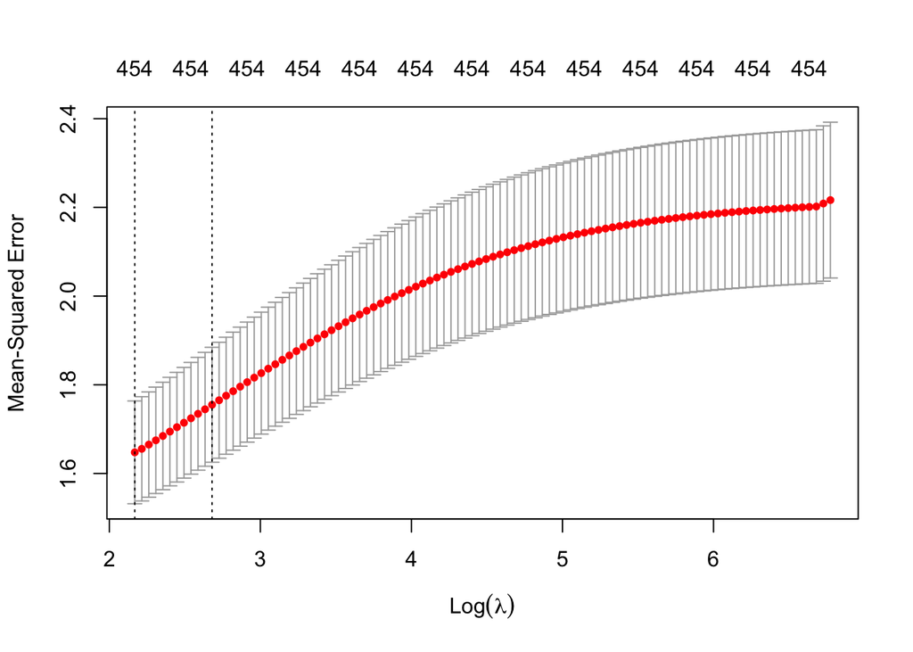

```r
data_ridge_cv<- cv.glmnet(
  x= data_train_x,
  y = data_train_y,
  alpha = 0
)

plot(data_ridge_cv)
```

Mínimo MSE

```r
min(data_ridge_cv$cvm)
```

```
## [1] 1.647659
```

Lambda para ese min MSE

```r
data_ridge_cv$lambda.min
```

```
## [1] 8.744999
```

```r
log(data_ridge_cv$lambda.min)
```

```
## [1] 2.168482
```

Calculo el st.error de min MSE

```r
data_ridge_cv$cvm[data_ridge_cv$lambda == data_ridge_cv$lambda.1se]
```

```
## [1] 1.754934
```

Saco el lambda para ese MSE

```r
data_ridge_cv$lambda.1se
```

```
## [1] 14.58754
```

```r
log(data_ridge_cv$lambda.1se)
```

```
## [1] 2.680168
```

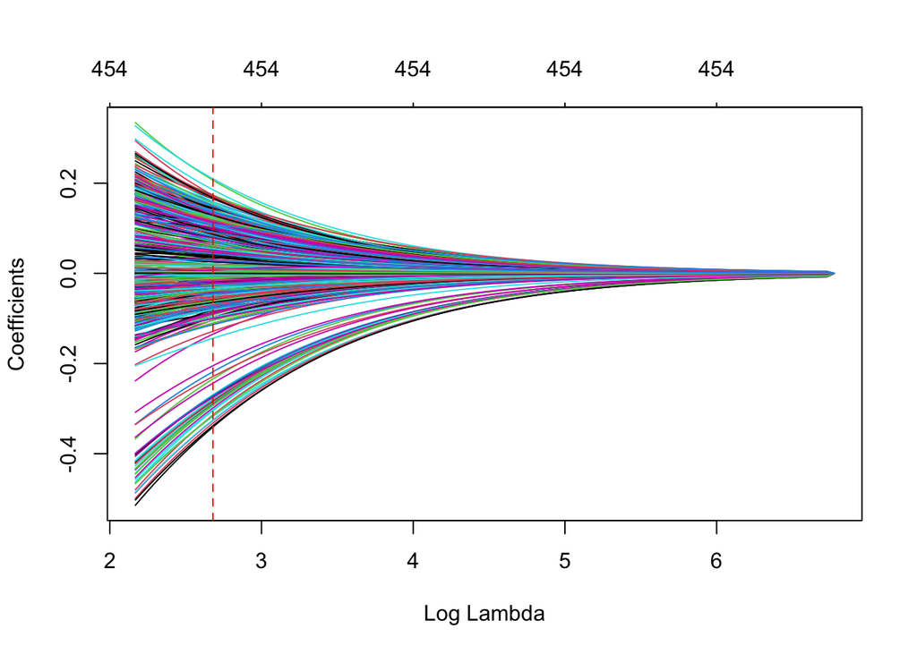

```r
plot(data_ridge, xvar = "lambda")
abline(v = log( data_ridge_cv$lambda.1se), col = "red", lty = "dashed")
```

## Ventajas y Desventajas

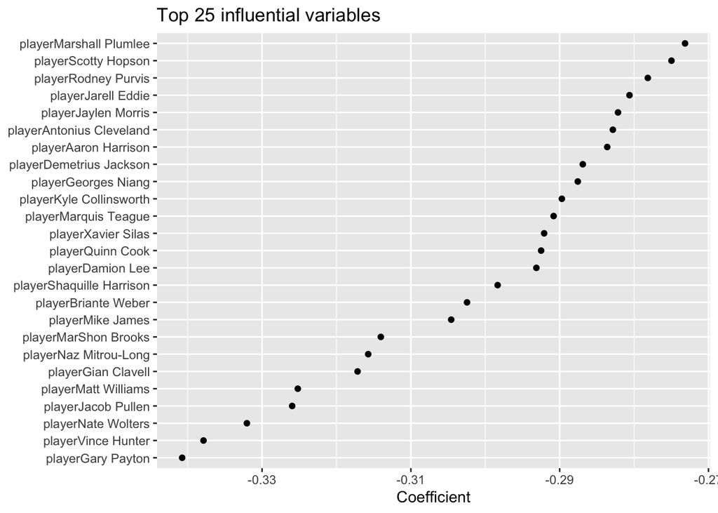

```r
coef(data_ridge_cv, s = "lambda.1se") %>%
  broom::tidy() %>%
  filter(row != "(Intercept)") %>%
  top_n(25, wt = abs(value)) %>%
  ggplot(aes(value, reorder(row, value))) +
  geom_point() +
  ggtitle("Top 25 influential variables") +
  xlab("Coefficient") +
  ylab(NULL)
```

Una regresión cresta conserva todas las variables, por lo que para una mayor interpretación voy a realizar un modelo lasso que reduce la señal en sus datos a un subconjunto más pequeño.

## LASSO

alpha = 1

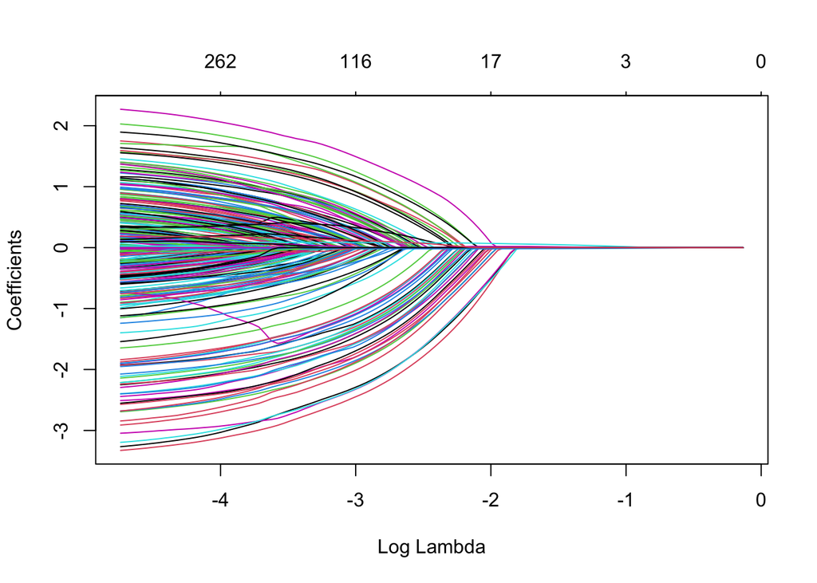

```r
data_lasso <- glmnet (
  x = data_train_x,
  y = data_train_y,
  alpha = 1
)

plot(data_lasso, xvar = "lambda")
```

## TUNNING - CV

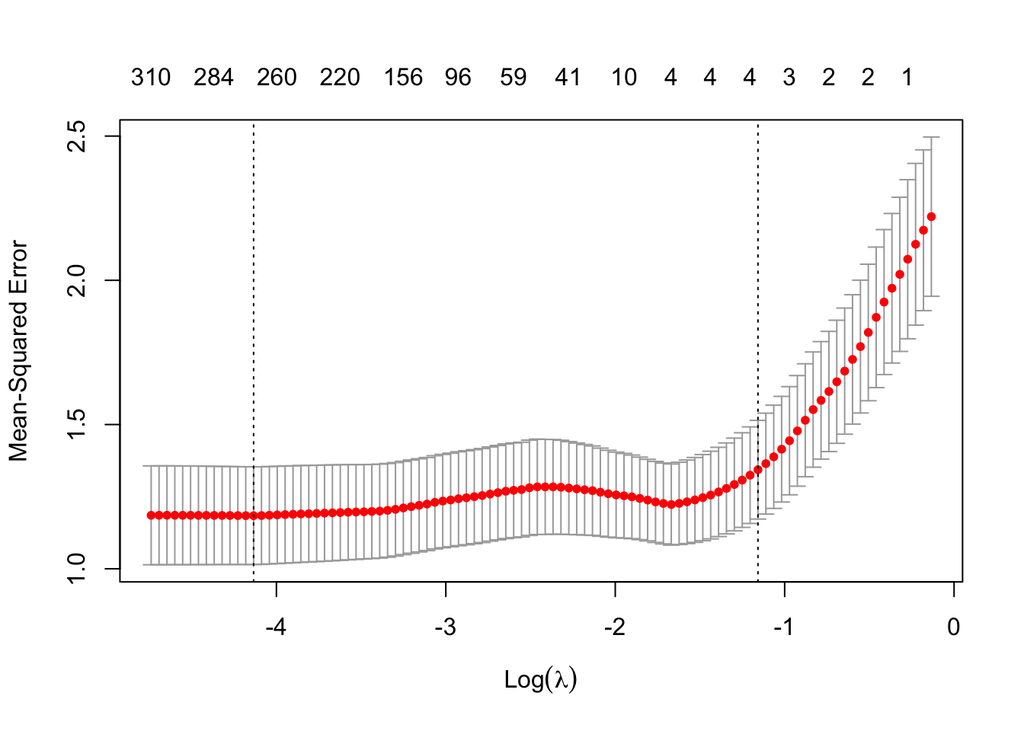

```r
data_lasso_cv <- cv.glmnet(
  x = data_train_x,
  y = data_train_y,
  alpha = 1
)
# plot results
plot(data_lasso_cv)
```

Mínimo MSE

```r
min(data_lasso_cv$cvm)
```

```
## [1] 1.184022
```

Lambda para ese mínimo

```r
data_lasso_cv$lambda.min
```

```
## [1] 0.01600981
```

1 st. error de min MSE

```r
data_lasso_cv$cvm[data_lasso_cv$lambda == data_lasso_cv$lambda.1se]
```

```
## [1] 1.343344
```

Lambda para ese MSE

```r
data_lasso_cv$lambda.1se
```

```
## [1] 0.314279
```

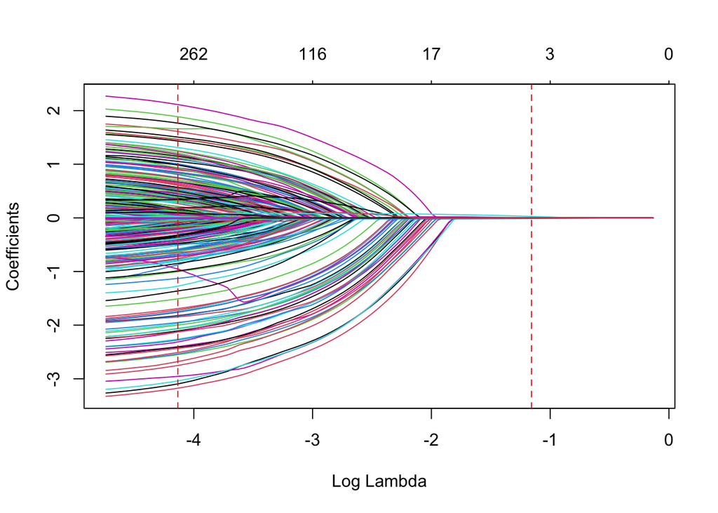

```r
plot(data_lasso, xvar = "lambda")
abline(v = log(data_lasso_cv$lambda.min), col = "red", lty = "dashed")
abline(v = log(data_lasso_cv$lambda.1se), col = "red", lty = "dashed")
```

Entre esos dos lambda hay el mismo error de predicción.

## Variables Influyentes:

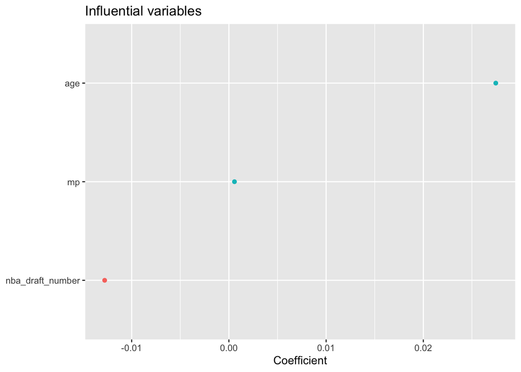

```r
coef(data_lasso_cv, s = "lambda.1se") %>%
  tidy() %>%
  filter(row != "(Intercept)") %>%
  ggplot(aes(value, reorder(row, value), color = value > 0)) +
  geom_point(show.legend = FALSE) +
  ggtitle("Influential variables") +
  xlab("Coefficient") +
  ylab(NULL)
```

Mínimo ridge MSE

```r
min(data_ridge_cv$cvm)
```

```
## [1] 1.647659
```

```r
min(data_lasso_cv$cvm)
```

```
## [1] 1.184022
```

Calculando el mínimo que coge el Ridge y el Lasso se observa que se comporta mejor el lasso.

## ELASTIC NET

Primero decido el alpha y luego establezco el lambda de cada modelo.

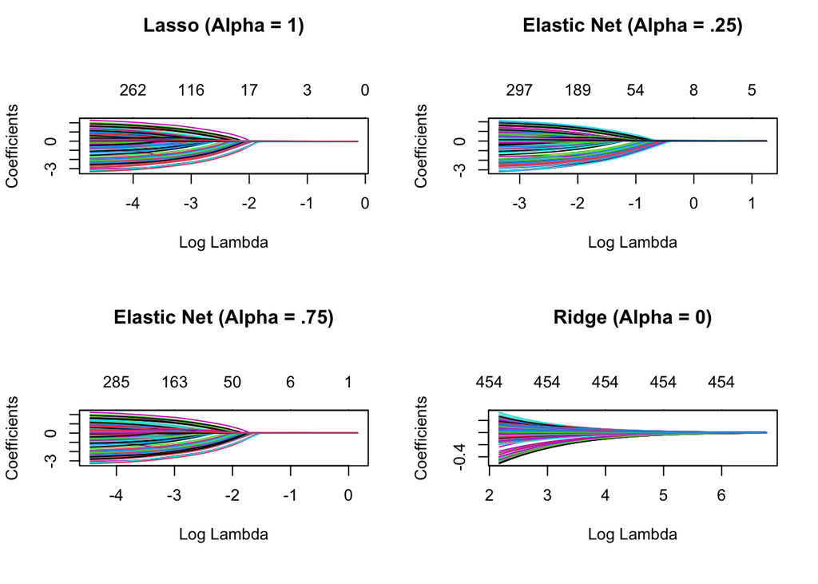

```r
lasso    <- glmnet(data_train_x, data_train_y, alpha = 1.0)
elastic1 <- glmnet(data_train_x, data_train_y, alpha = 0.25)
elastic2 <- glmnet(data_train_x, data_train_y, alpha = 0.75)
ridge    <- glmnet(data_train_x, data_train_y, alpha = 0.0)

par(mfrow = c(2, 2), mar = c(6, 4, 6, 2) + 0.1)
plot(lasso, xvar = "lambda", main = "Lasso (Alpha = 1)\n\n\n")
plot(elastic1, xvar = "lambda", main = "Elastic Net (Alpha = .25)\n\n\n")
plot(elastic2, xvar = "lambda", main = "Elastic Net (Alpha = .75)\n\n\n")
plot(ridge, xvar = "lambda", main = "Ridge (Alpha = 0)\n\n\n")
```

Para cada alpha elijo el mejor lambda.

## TUNNING

```r
fold_id <- sample(1:10, size = length(data_train_y), replace=TRUE)

# search across a range of alphas
tuning_grid <- tibble::tibble(
  alpha      = seq(0, 1, by = .1),
  mse_min    = NA,
  mse_1se    = NA,
  lambda_min = NA,
  lambda_1se = NA
)
tuning_grid
```

```
## # A tibble: 11 x 5
##    alpha mse_min mse_1se lambda_min lambda_1se
##    <dbl> <lgl>   <lgl>   <lgl>      <lgl>
##  1   0   NA      NA      NA         NA
##  2   0.1 NA      NA      NA         NA
##  3   0.2 NA      NA      NA         NA
##  4   0.3 NA      NA      NA         NA
##  5   0.4 NA      NA      NA         NA
##  6   0.5 NA      NA      NA         NA
##  7   0.6 NA      NA      NA         NA
##  8   0.7 NA      NA      NA         NA
##  9   0.8 NA      NA      NA         NA
## 10   0.9 NA      NA      NA         NA
## 11   1   NA      NA      NA         NA
```

Ahora lo voy a rellenar con el mínimo, desviación típica, lambda mínimo y desviación típica.

```r
for(i in seq_along(tuning_grid$alpha)) {

  # fit CV model for each alpha value
  fit <- cv.glmnet(data_train_x, data_train_y, alpha = tuning_grid$alpha[i], foldid = fold_id)

  # extract MSE and lambda values
  tuning_grid$mse_min[i]    <- fit$cvm[fit$lambda == fit$lambda.min]
  tuning_grid$mse_1se[i]    <- fit$cvm[fit$lambda == fit$lambda.1se]
  tuning_grid$lambda_min[i] <- fit$lambda.min
  tuning_grid$lambda_1se[i] <- fit$lambda.1se
}

tuning_grid
```

```
## # A tibble: 11 x 5
##    alpha mse_min mse_1se lambda_min lambda_1se
##    <dbl>   <dbl>   <dbl>      <dbl>      <dbl>
##  1   0      1.67    1.78      8.74      15.3
##  2   0.1    1.21    1.30      0.353      1.30
##  3   0.2    1.18    1.27      0.294      0.899
##  4   0.3    1.17    1.25      0.359      0.658
##  5   0.4    1.16    1.24      0.282      0.517
##  6   0.5    1.15    1.24      0.226      0.433
##  7   0.6    1.14    1.23      0.188      0.361
##  8   0.7    1.14    1.22      0.161      0.309
##  9   0.8    1.13    1.22      0.141      0.284
## 10   0.9    1.13    1.21      0.125      0.252
## 11   1      1.12    1.21      0.113      0.227
```

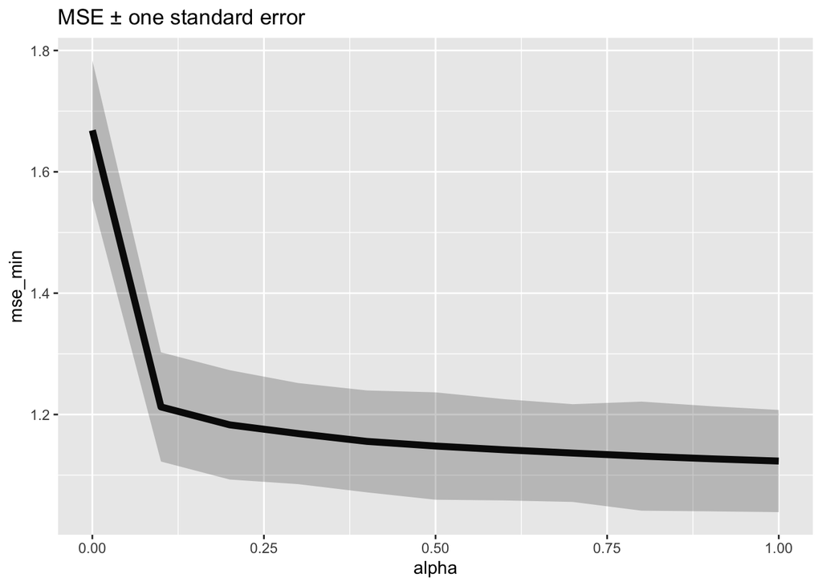

```r
tuning_grid %>%
  mutate(se = mse_1se - mse_min) %>%
  ggplot(aes(alpha, mse_min)) +
  geom_line(size = 2) +
  geom_ribbon(aes(ymax = mse_min + se, ymin = mse_min - se), alpha = .25) +
  ggtitle("MSE ± one standard error")
```

## PREDICCIÓN

Best model:

```r
cv_lasso   <- cv.glmnet(data_train_x, data_train_y, alpha = 1.0)
min(cv_lasso$cvm)
```

```
## [1] 1.142859
```

No hace falta hacer la predicción ya que anteriormente se ha observado que numéricamente el mejor modelo es el alpha = 1 que coincide con el modelo lasso, por lo que no lo voy a comparar con otro.